# One Sample Mean Testing

### **NOTES ON STATISTICS, PROBABILITY and MATHEMATICS**

### One Sample Mean to Population Comparison with Z and T Tests:

The one-sample z-test (or t-test) is used when we want to know whether our sample comes from a particular population but we may or may not have full population information (population standard deviation) available to us.

Motivating example:

> Suppose that we wanted to detect whether a sample mean in a hospital is higher than the national mean of the RDI (respiratory disturbance index) in the context of sleep apnea. Assume normality and that the sample in question has a standard deviation of $4$.

**We test whether the population mean is bigger than a reference accepted value ($\mu_0=30$) based on the mean obtained from sample $(\bar X)$.**

We compare the sample mean, $\bar X$ to a constant $C$ so that the probability of a type I error is $\alpha$ (typically $0.05$ or $5\%$):

$0.05 = \Pr\left (\bar X \geq C \mid \mu_o =30 \right)$

Normalizing:

$0.05\,=\Pr \left (\frac{\bar X - \mu_o}{s/\sqrt{n}}\,\geq\frac{C - \mu_o}{s/\sqrt{n}} \mid \mu_o=30 \right)$

For this to be true the second part of the inequality must be equal to:

$\frac{C - \mu_o}{s/\sqrt{n}}$ `= qnorm(0.95)= 1.6448`

And the first part of the inequality is really the *Z-statistic*:

$\text{Z test statistic} = \frac{\bar X - \mu_o}{s/\sqrt{n}}$

Before we can do a Z-test, in general we need to make check if we can reasonably treat the mean of this sample as normally distributed (also for a t-test) (see [discussion for two samples here](https://stats.stackexchange.com/a/204594/67822)), and we have enough data for a Z test:

1. The data comes from a normal distribution.
2. How much data do we need? Many textbooks use $30$ data points as a rule of thumb.

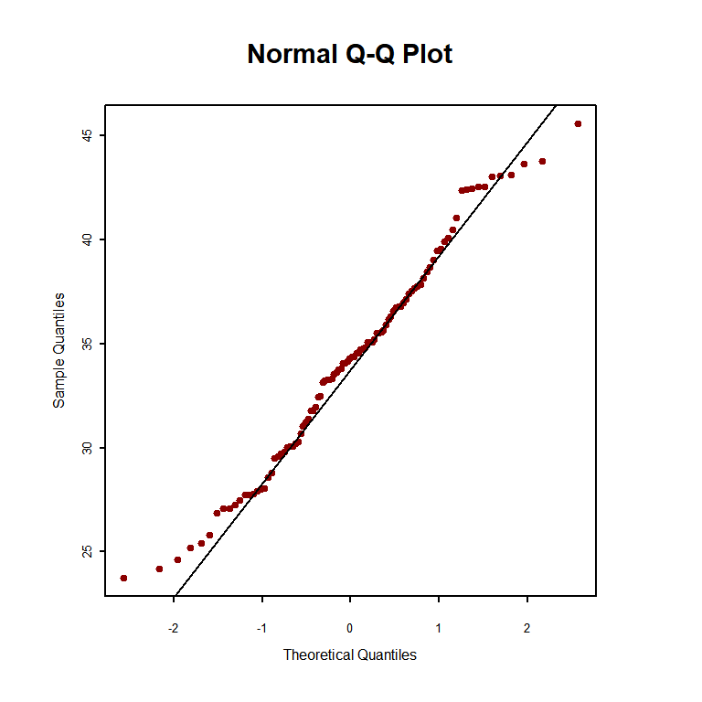

```r
set.seed(2021)
n <- 100
sample <- rnorm(n, 35, 5) # The actual sample values.
par(mar=c(3,3,3,3))
par(mgp=c(1,0.2,0))
qqnorm(sample, pch=19, cex=0.5, cex.main = .9, cex.lab = .5, cex.axis =.4, tck = -.01, col='red4')
qqline(sample)
```

Here is the Z-test using the package `BSDA`. First (even though we are deviating from the example above) the two-sided alternative):

```r
library(BSDA)
sigma <- 4   # Population standard deviation:
mu    <- 30  # Population mean
z.test(sample, mu=mu, sigma.x=sigma)
```

```
##
##  One-sample z-Test
##
## data:  sample
## z = 10.319, p-value < 2.2e-16
## alternative hypothesis: true mean is not equal to 30
## 95 percent confidence interval:
##  33.34359 34.91156
## sample estimates:
## mean of x
##  34.12758
```

Manually, and following [this post](https://cran.r-project.org/web/packages/distributions3/vignettes/one-sample-z-test.html):

```r
# calculate the z-statistic
paste('The z statistic is', z_stat <- (mean(sample) - mu) / (sigma / sqrt(n)))
```

```
## [1] "The z statistic is 10.3189449413837"
```

```r
paste('The p-value is', 2 * (1 - pnorm(z_stat)))
```

```
## [1] "The p-value is 0"
```

```r
paste('The CI is between', mean(sample) - qnorm(0.975) * sigma / sqrt(n),'and', mean(sample) + qnorm(0.975) * sigma / sqrt(n) )
```

```
## [1] "The CI is between 33.3435923827374 and 34.9115635703695"
```

And finally, the one-sided test assesses whether the mean is larger than the population mean:

```r
z.test(sample, mu=mu, sigma.x=sigma, alternative='greater')
```

```
##
##  One-sample z-Test
##
## data:  sample
## z = 10.319, p-value < 2.2e-16
## alternative hypothesis: true mean is greater than 30
## 95 percent confidence interval:
##  33.46964       NA
## sample estimates:
## mean of x
##  34.12758
```

which manually would work like:

```r
paste('The z statistic is', z_stat <- (mean(sample) - mu) / (sigma / sqrt(n)))
```

```
## [1] "The z statistic is 10.3189449413837"
```

```r
paste('The p-value is', 1 - pnorm(z_stat))
```

```
## [1] "The p-value is 0"
```

```r
paste('The CI is between', mean(sample) - qnorm(0.95) * sigma / sqrt(n),'and infinity.')
```

```
## [1] "The CI is between 33.4696365257729 and infinity."
```

If $n$ is small we will do exactly the same thing but with a $t$ test:

$\frac{C - \mu_o}{s/\sqrt{n}}$ `= qt(0.95, n - 1)`

To test whether the sample mean is different to the population mean:

For instance, if the sample mean is greater:

```r
n <- 15
sample <- rnorm(n, 35, 5)
t.test(sample, mu=30)
```

```
##
##  One Sample t-test
##
## data:  sample
## t = 2.2079, df = 14, p-value = 0.04443
## alternative hypothesis: true mean is not equal to 30
## 95 percent confidence interval:
##  30.07617 35.25081
## sample estimates:
## mean of x
##  32.66349
```

For a one-sided test to assess if the sample mean is greater:

```r
set.seed(2021)
n <- 15
sample <- rnorm(n, 35, 5)
t.test(sample, mu=30, alternative = 'greater')
```

```
##
##  One Sample t-test
##
## data:  sample
## t = 5.2614, df = 14, p-value = 6.016e-05
## alternative hypothesis: true mean is greater than 30
## 95 percent confidence interval:
##  34.42933      Inf
## sample estimates:
## mean of x
##  36.65826
```

**what if we don’t have the sample vector, but rather just the sample standard deviation and the mean?**

Let’s say the mean is 36.65826, which is `mean(sample)` as above, but instead of plugging in the sample into the function, we just have the $\bar x$ value or sample mean, and the sample standard deviation (or the population’s, perhaps).

Incredibly we need an *ad hoc* function! Which for a one-sided (‘greater’) test involves the following calculation:

```r
mu <- 30                 # Population mean
x.bar <- mean(sample)    # Sample mean
n <- 15                  # Sample size
se <- sd(sample)         # Sample SD
t <- (x.bar - mu) / (se/sqrt(n)) # t statistic

# Which is greater than:
qt(0.95, n - 1) # We test for a 'greater' alternative hypothesis.
```

```
## [1] 1.76131
```

```r
# This corresponds to a p-value of
1 - pt(abs(t), n - 1)
```

```
## [1] 6.016346e-05
```

```r
# And for lower bound of confidence intervals (see below for formula derivation):

x.bar - qt(0.95, n - 1) * se/sqrt(n)
```

```
## [1] 34.42933
```

[What follows was first posted on [CrossValidated](http://stats.stackexchange.com/a/175142/67822)]

Example:

> We know that mean glucose concentration in blood is `100 mg/dL`, and we are studying an ethnic group with very low prevalence of metabolic syndrome. We sample 100 of these individuals, and we get a `mean [glucose] = 98 mg/dL` with a `sd = 10 mg/dL`. Is it reasonable to conclude with a risk alpha of 5% that this group has lower glucose levels than the general population?

When sample size is larger than 30, we can consider using a z-test. Typically the standard deviation of the sample will have to be used to substitute for the unknown parameter. In the example above we want a left-tailed test: $\small H_1: \bar X < \mu$. We use the central limit theorem, which tells us that the sample distribution of the sample means has a standard error, $\small SE=\frac{\sigma}{\sqrt n}$, with $\sigma$ corresponding to the population standard deviation, and we get the following statistic:

$$z = \frac{\bar X -
\mu}{\frac{\sigma}{\sqrt n}}$$
If $\sigma$ is unknown we have to use the unbiased SD of the sample $z = \frac{\bar X - \mu}{\frac{s}{\sqrt n}}.$

In our example: `z= (98-100)/(10/sqrt(100)) = -2`, which needs to be compared to `qnorm(0.05) = -1.644854`. Therefore we reject the $\small H_0: \bar X=\mu$.

```r
x.bar = 98
mu = 100
s = 10
n = 100
paste('The z statistic is', z_stat <- (x.bar - mu) / (s / sqrt(n)))
```

```
## [1] "The z statistic is -2"
```

```r
paste('The p-value is', pnorm(z_stat))
```

```
## [1] "The p-value is 0.0227501319481792"
```

**Is the Mean of a Small Sample Consistent with Known Population Mean?**

Consider the example above, but with a sample size of `n = 16` individuals. The distribution of the same statistic would follow a $t$-distribution, and the test applied is the “one-sample $t$ test”:

$t = \frac{\bar X - \mu}{\frac{s}{\sqrt n}}$.

```r
x.bar = 98
mu = 100
s = 10
n = 16
paste('The t statistic is', t_stat <- (x.bar - mu) / (s / sqrt(n)))
```

```
## [1] "The t statistic is -0.8"
```

```r
paste('The p-value is', pt(t_stat, n - 1))
```

```
## [1] "The p-value is 0.218098969581344"
```

**Confidence Interval Calculation:**

Under $H_0$, $\left| \frac{\bar X - \mu}{\frac{\sigma}{\sqrt n}}\right|\leq t_{(1-\alpha/2, \,n - 1)}$. Hence, $\left| \bar X - \mu\right|\leq t_{(1-\alpha/2, \,n - 1)}\, \frac{\sigma}{\sqrt n}$, or:

$$\bar X- t_{(1-\alpha/2, \,n - 1)}\,
\frac{\sigma}{\sqrt n}\, <\mu<\bar X + t_{(1-\alpha/2, \,n - 1)}\,
\frac{\sigma}{\sqrt n}$$

In R,

```r
x.bar + c(-1,1) * qt(1 - 0.5/2, n - 1) * s / sqrt(n)
```

```
## [1] 96.27201 99.72799
```

Alternatively, the confidence interval can be calculated using the normal distribution in larger samples (let’s imagine `n=100`), using the formula: `n = 100; 98 + c(-1,1) * qnorm(1 - 0.5/2) * 10/sqrt(n)`.

Altogether, this would be the calculation in R:

```r
mu <- 100                 # Population mean
x.bar <- 98               # Sample mean
n <- 16                   # Sample size
sd <- 10                  # Sample SD
(t <- (x.bar - mu) / (sd/sqrt(n))) # t statistic
```

```
## [1] -0.8
```

```r
# Which is not lower than:
qt(0.05, n - 1)
```

```
## [1] -1.75305
```

```r
# And therefore we don't reject the null.

# This corresponds to a p-value of
pt(t, n - 1)
```

```
## [1] 0.218099
```

```r
# And for upper bound of confidence intervals:

x.bar + qt(0.05, n - 1) * sd/sqrt(n)
```

```
## [1] 93.61737
```

**When we have summary statistics only but two means to compare** we can use the function:

```
# m1, m2: the sample means
# s1, s2: the sample standard deviations
# n1, n2: the same sizes
# m0: the null value for the difference in means to be tested for. Default is 0.
# equal.variance: whether or not to assume equal variance. Default is FALSE.
t.test2 <- function(m1,m2,s1,s2,n1,n2,m0=0,equal.variance=FALSE)
{
    if( equal.variance==FALSE )
    {
        se <- sqrt( (s1^2/n1) + (s2^2/n2) )
        # welch-satterthwaite df
        df <- ( (s1^2/n1 + s2^2/n2)^2 )/( (s1^2/n1)^2/(n1-1) + (s2^2/n2)^2/(n2-1) )
    } else
    {
        # pooled standard deviation, scaled by the sample sizes
        se <- sqrt( (1/n1 + 1/n2) * ((n1-1)*s1^2 + (n2-1)*s2^2)/(n1+n2-2) )
        df <- n1+n2-2
    }
    t <- (m1-m2-m0)/se
    dat <- c(m1-m2, se, t, 2*pt(-abs(t),df))
    names(dat) <- c("Difference of means", "Std Error", "t", "p-value")
    return(dat)
}
```

from [this post](https://stats.stackexchange.com/a/30450/67822).

References:

[Basic Inferential Calculations with only Summary Statistics](https://stats.stackexchange.com/questions/175141/basic-inferential-calculations-with-only-summary-statistics-available/175142#175142)

[Home Page](http://rinterested.github.io/statistics/index.html)

**NOTE: These are tentative notes on different topics for personal use - expect mistakes and misunderstandings.**